# Stout Case Study

Jas Dinh

April 12, 2022

## Customer Revenue Report 2015-2017

For each year we need the following information:

- Total revenue for the current year
- New Customer Revenue e.g. new customers not present in previous year only
- Existing Customer Growth. To calculate this, use the Revenue of existing customers for current year –(minus) Revenue of existing customers from the previous year
- Revenue lost from attrition
- Existing Customer Revenue Current Year
- Existing Customer Revenue Prior Year
- Total Customers Current Year
- Total Customers Previous Year
- New Customers
- Lost Customers

```r
casestudy = read.csv("casestudy.csv") # vars: index, email, net revenue, year
```

```r
library(dplyr)
```

```r
library(ggplot2)
library(scales)
```

## 2015

```r
dat15 <- casestudy %>% filter(year == "2015")
dat16 <- casestudy %>% filter(year == "2016")
dat17 <- casestudy %>% filter(year == "2017")
```

```r
# Total revenue for the current year
sum(dat15$net_revenue)
```

```
## [1] 29036749
```

```r
# New Customer Revenue e.g. new customers not present in previous year only
    # Previous year data not provided
# Existing Customer Growth. To calculate this, use the Revenue of existing customers for current year –(minus) Revenue of existing customers from the previous year
    # Previous year data not provided
# Revenue lost from attrition
    # Previous year data not provided
# Existing Customer Revenue Current Year
    # same as total revenue
# Existing Customer Revenue Prior Year
    # Previous year data not provided
# Total Customers Current Year
count(dat15)
```

```
##        n
## 1 231294
```

```r
# Total Customers Previous Year
    # Previous year data not provided
# New Customers
    # same as total customers
# Lost Customers
    # Previous year data not provided
```

The total revenue for 2015 is $29,036,749 and the total customers is 231,294 people.

## 2016

```r
existing1516 <- inner_join(dat16, dat15, by = "customer_email")
new16 <- anti_join(dat16, dat15, by = "customer_email")
old15 <- anti_join(dat15, dat16, by = "customer_email")

# Total revenue for the current year
sum(dat16$net_revenue)
```

```
## [1] 25730944
```

```r
# New Customer Revenue e.g. new customers not present in previous year only
sum(new16$net_revenue)
```

```
## [1] 18245491
```

```r
# Existing Customer Growth. To calculate this, use the Revenue of existing customers for current year –(minus) Revenue of existing customers from the previous year
sum(existing1516$net_revenue.x) - sum(existing1516$net_revenue.y)
```

```
## [1] 20335.46
```

```r
# Revenue lost from attrition
sum(old15$net_revenue)
```

```
## [1] 21571632
```

```r
# Existing Customer Revenue Current Year
sum(existing1516$net_revenue.x)
```

```
## [1] 7485453
```

```r
# Existing Customer Revenue Prior Year
sum(existing1516$net_revenue.y)
```

```
## [1] 7465117
```

```r
# Total Customers Current Year
count(dat16)
```

```
##        n
## 1 204646
```

```r
# Total Customers Previous Year
count(dat15)
```

```
##        n
## 1 231294
```

```r
# New Customers
count(new16)
```

```
##        n
## 1 145062
```

```r
# Lost Customers
count(old15)
```

```
##        n
## 1 171710
```

The total revenue for 2016 is $25,730,944 and the new customer revenue is $18,245,491. The existing customer growth is $20,335.46 and the revenue lost from attrition is $21,571,632. The existing customer revenue for 2016 is $7,485,453 and the existing customer revenue for 2015 is $7,465,117. The total customers for the 2016 is 204,646 people and the total customers for 2015 is 231,294 people. The amount of new customers is 145,062 people and the amount of lost customers is 171,710 people.

## 2017

```r
existing1617 <- inner_join(dat17, dat16, by = "customer_email")
new17 <- anti_join(dat17, dat16, by = "customer_email")
old16 <- anti_join(dat16, dat17, by = "customer_email")

# Total revenue for the current year
sum(dat17$net_revenue)
```

```
## [1] 31417495
```

```r
# New Customer Revenue e.g. new customers not present in previous year only
sum(new17$net_revenue)
```

```
## [1] 28776235
```

```r
# Existing Customer Growth. To calculate this, use the Revenue of existing customers for current year –(minus) Revenue of existing customers from the previous year
sum(existing1617$net_revenue.x) - sum(existing1617$net_revenue.y)
```

```
## [1] 20611.34
```

```r
# Revenue lost from attrition
sum(old16$net_revenue)
```

```
## [1] 23110295
```

```r
# Existing Customer Revenue Current Year
sum(existing1617$net_revenue.x)
```

```
## [1] 2641260
```

```r
# Existing Customer Revenue Prior Year
sum(existing1617$net_revenue.y)
```

```
## [1] 2620649
```

```r
# Total Customers Current Year
count(dat17)
```

```
##        n
## 1 249987
```

```r
# Total Customers Previous Year
count(dat16)
```

```
##        n
## 1 204646
```

```r
# New Customers
count(new17)
```

```
##        n
## 1 229028
```

```r
# Lost Customers
count(old16)
```

```
##        n
## 1 183687
```

## Data Visualizations

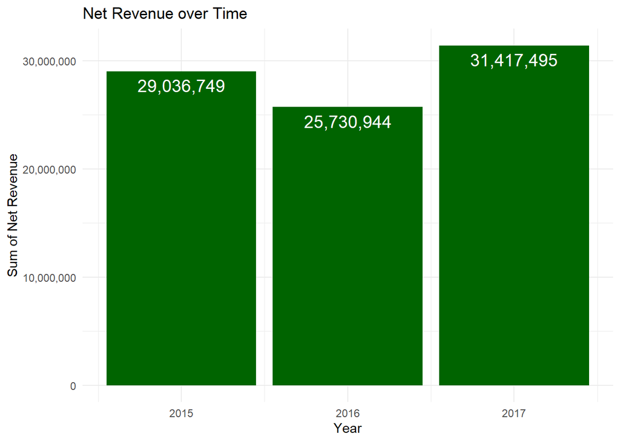

```r
revSum <- casestudy %>% group_by(year) %>% summarize(netSum = sum(net_revenue))
ggplot(revSum, aes(x = year, y= netSum)) + geom_bar(stat = "identity", fill = "dark green") + labs(title = "Net Revenue over Time", x= "Year", y = "Sum of Net Revenue") +   geom_text(aes(label= scales::comma(netSum)), vjust=1.6, color="white", size=5)+ scale_y_continuous(labels = comma) + theme_minimal()
```

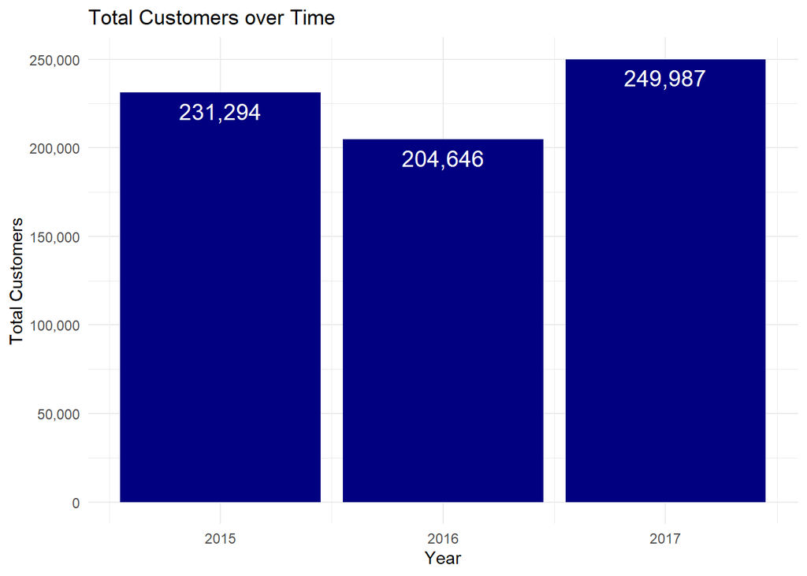

```r
custSum <- casestudy %>% group_by(year) %>% summarize(customers = n())
ggplot(custSum, aes(x = year, y= customers)) + geom_bar(stat = "identity", fill = "navy blue") + labs(title = "Total Customers over Time", x= "Year", y = "Total Customers") +   geom_text(aes(label= scales::comma(customers)), vjust=1.6, color="white", size=5) + scale_y_continuous(labels = comma) + theme_minimal()
```

With these visualizations, we can see that 2017 was the company’s best-performing year with the most customers and net revenue while 2016 was the company’s worst-performing year.